# STATISTICS slides

##### Statistics - The science of collecting,organizing & analyzing data.

##### Data - Facts or piece of information that can be measured.

##### Statistics is used for better decision making

## Descriptive Statistics

##### - It consists of organizing & summarizing data

### 1)Measure Of Central Tendency

```python
import numpy as np
import pandas as pd
import seaborn as sns
import matplotlib.pyplot as plt
%matplotlib inline
```

#### MEAN

##### Ratio of sum of all observations to no.of observations

```python
arr = np.array([4,5,6,2,1,8,5,6,4,7])
```

```python
np.sum(arr)/len(arr)
```

```
4.8
```

```python
np.mean(arr)
```

```
4.8
```

```python
dts = pd.read_csv("titanic.csv")
dts.head()
```

|  | PassengerId | Survived | Pclass | Name | Sex | Age | SibSp | Parch | Ticket | Fare | Cabin | Embarked |
| --- | --- | --- | --- | --- | --- | --- | --- | --- | --- | --- | --- | --- |
| 0 | 892 | 0 | 3 | Kelly, Mr. James | male | 34.5 | 0 | 0 | 330911 | 7.8292 | NaN | Q |
| 1 | 893 | 1 | 3 | Wilkes, Mrs. James (Ellen Needs) | female | 47.0 | 1 | 0 | 363272 | 7.0000 | NaN | S |
| 2 | 894 | 0 | 2 | Myles, Mr. Thomas Francis | male | 62.0 | 0 | 0 | 240276 | 9.6875 | NaN | Q |
| 3 | 895 | 0 | 3 | Wirz, Mr. Albert | male | 27.0 | 0 | 0 | 315154 | 8.6625 | NaN | S |
| 4 | 896 | 1 | 3 | Hirvonen, Mrs. Alexander (Helga E Lindqvist) | female | 22.0 | 1 | 1 | 3101298 | 12.2875 | NaN | S |

```python
dts.describe()
```

|  | PassengerId | Survived | Pclass | Age | SibSp | Parch | Fare |
| --- | --- | --- | --- | --- | --- | --- | --- |
| count | 418.000000 | 418.000000 | 418.000000 | 332.000000 | 418.000000 | 418.000000 | 418.000000 |
| mean | 1100.500000 | 0.363636 | 2.265550 | 30.272590 | 0.447368 | 0.392344 | 35.553655 |
| std | 120.810458 | 0.481622 | 0.841838 | 14.181209 | 0.896760 | 0.981429 | 55.860735 |
| min | 892.000000 | 0.000000 | 1.000000 | 0.170000 | 0.000000 | 0.000000 | 0.000000 |
| 25% | 996.250000 | 0.000000 | 1.000000 | 21.000000 | 0.000000 | 0.000000 | 7.895800 |
| 50% | 1100.500000 | 0.000000 | 3.000000 | 27.000000 | 0.000000 | 0.000000 | 14.454200 |
| 75% | 1204.750000 | 1.000000 | 3.000000 | 39.000000 | 1.000000 | 0.000000 | 31.471875 |
| max | 1309.000000 | 1.000000 | 3.000000 | 76.000000 | 8.000000 | 9.000000 | 512.329200 |

```python
dts.info()
```

```
<class 'pandas.core.frame.DataFrame'>
RangeIndex: 418 entries, 0 to 417
Data columns (total 12 columns):
 #   Column       Non-Null Count  Dtype
---  ------       --------------  -----
 0   PassengerId  418 non-null    int64
 1   Survived     418 non-null    int64
 2   Pclass       418 non-null    int64
 3   Name         418 non-null    object
 4   Sex          418 non-null    object
 5   Age          332 non-null    float64
 6   SibSp        418 non-null    int64
 7   Parch        418 non-null    int64
 8   Ticket       418 non-null    object
 9   Fare         418 non-null    float64
 10  Cabin        91 non-null     object
 11  Embarked     418 non-null    object
dtypes: float64(2), int64(5), object(5)
memory usage: 39.3+ KB
```

```python
dts["Age"].mean()
```

```
30.272590361445783
```

```python
mn = np.mean(dts["Age"])
mn
```

```
30.272590361445783
```

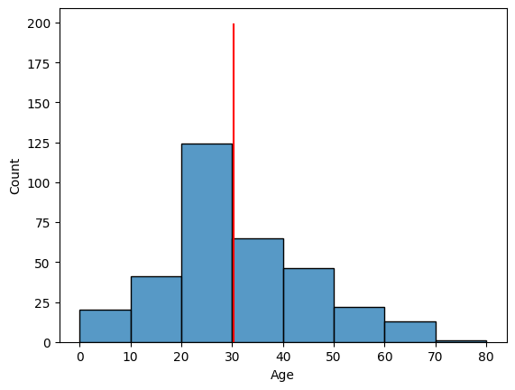

```python
sns.histplot(x="Age",data=dts,bins=[i for i in range(0,81,10)])
plt.plot([mn for i in range(0,200)],[i for i in range(0,200)],c = "red")
plt.show()
```

#### MEDIAN

##### Middle element

```python
# Checking if the data set contains null values
dts.isnull().sum()
```

```
PassengerId      0
Survived         0
Pclass           0
Name             0
Sex              0
Age             86
SibSp            0
Parch            0
Ticket           0
Fare             0
Cabin          327
Embarked         0
dtype: int64
```

```python
np.median(dts["Age"])
```

```
nan
```

#### Filling the null values in the data set

```python
dts["Age"].fillna(dts["Age"].mean(),inplace=True)
```

```python
dts["Fare"].fillna(dts["Fare"].mean(),inplace=True)
```

```python
dts.isnull().sum()
```

```
PassengerId      0
Survived         0
Pclass           0
Name             0
Sex              0
Age              0
SibSp            0
Parch            0
Ticket           0
Fare             0
Cabin          327
Embarked         0
dtype: int64
```

```python
np.median(dts["Age"])
```

```
30.272590361445783
```

```python
dts["Fare"].median()
```

```
14.4542
```

```python
med = np.median(dts["Fare"])
med
```

```
14.4542
```

```python
dts["Fare"].mean()
```

```
35.55365454545454
```

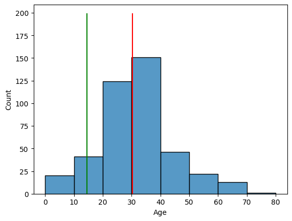

```python
sns.histplot(x="Age",data=dts,bins=[i for i in range(0,81,10)])
plt.plot([mn for i in range(0,200)],[i for i in range(0,200)],c = "red")
plt.plot([med for i in range(0,200)],[i for i in range(0,200)],c = "green")
plt.show()
```

#### MODE

##### Most-occuring element

```python
type(dts["Fare"].mode())
```

```
pandas.core.series.Series
```

```python
dts["Fare"].mode()
```

```
0    7.75
Name: Fare, dtype: float64
```

```python
mod = dts["Fare"].mode()[0]
mod
```

```
7.75
```

```python
dts["Fare"].value_counts()
```

```
Fare
7.7500     21
26.0000    19
8.0500     17
13.0000    17
10.5000    11
           ..
8.7125      1
7.8208      1
8.5167      1
78.8500     1
22.3583     1
Name: count, Length: 170, dtype: int64
```

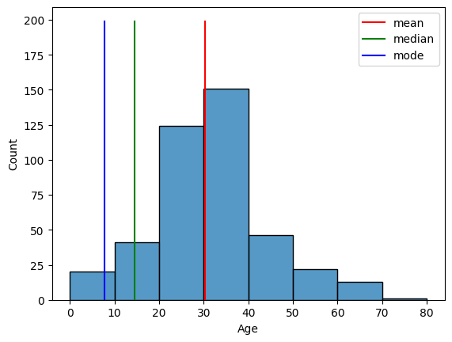

```python
sns.histplot(x="Age",data=dts,bins=[i for i in range(0,81,10)])
plt.plot([mn for i in range(0,200)],[i for i in range(0,200)],c = "red",label="mean")
plt.plot([med for i in range(0,200)],[i for i in range(0,200)],c = "green",label="median")
plt.plot([mod for i in range(0,200)],[i for i in range(0,200)],c = "blue",label="mode")
plt.legend()
plt.show()
```

### 2)Measure Of Variability - Spreadness

#### RANGE :- MAX-MIN

```python
min_d = dts["Age"].min()
max_d = dts["Age"].max()
```

```python
min_d,max_d
```

```
(0.17, 76.0)
```

```python
range1 = max_d - min_d
range1
```

```
75.83
```

```python
min_r = dts["Fare"].min()
max_r = dts["Fare"].max()
```

```python
min_r,max_r
```

```
(0.0, 512.3292)
```

```python
range2 = max_r - min_r
range2
```

```
512.3292
```

```python
d1 = pd.read_csv("tips.csv")
d1.head(3)
```

|  | total_bill | tip | sex | smoker | day | time | size |
| --- | --- | --- | --- | --- | --- | --- | --- |
| 0 | 16.99 | 1.01 | Female | No | Sun | Dinner | 2 |
| 1 | 10.34 | 1.66 | Male | No | Sun | Dinner | 3 |
| 2 | 21.01 | 3.50 | Male | No | Sun | Dinner | 3 |

```python
mind = d1["total_bill"].min()
maxd = d1["total_bill"].max()
```

```python
mind,maxd
```

```
(3.07, 50.81)
```

```python
range2 = maxd - mind
range2
```

```
47.74
```

#### MAD - MEAN ABSOLUTE DEVIATION

```python
sec1 = np.array([75,65,73,68,72,67])
sec2 = np.array([90,47,43,96,93,51])
no = np.array([1,2,3,4,5,6])
```

```python
a = np.mean(sec1)
a
```

```
70.0
```

```python
b = np.mean(sec2)
b
```

```
70.0
```

```python
mn = [70,70,70,70,70,70]
```

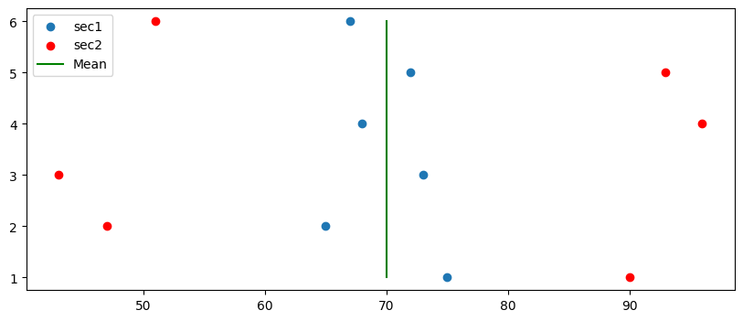

```python
plt.figure(figsize=(10,4))
plt.scatter(sec1,no,label="sec1")
plt.scatter(sec2,no,c="red",label="sec2")
plt.plot(mn,no,c="green",label="Mean")
plt.legend()
plt.show()
```

```python
mad1 = np.sum(np.abs(sec1-sec1.mean()))/len(sec1)
mad2 = np.sum(np.abs(sec2-sec2.mean()))/len(sec2)
mad1,mad2
```

```
(3.3333333333333335, 23.0)
```

```python
m1 = np.mean(np.abs(sec1-sec1.mean()))
m2 = np.mean(np.abs(sec2-sec2.mean()))
m1,m2
```

```
(3.3333333333333335, 23.0)
```

#### VARIANCE

##### It is a measure of how data points differ from mean

```python
np.var(sec1),np.var(sec2)
```

```
(12.666666666666666, 537.3333333333334)
```

```python
var1 = np.sum(np.abs(sec1-sec1.mean())**2)/len(sec1)
var2 = np.sum(np.abs(sec2-sec2.mean())**2)/len(sec2)
var1,var2
```

```
(12.666666666666666, 537.3333333333334)
```

```python
dataset1 = pd.read_csv("titanic.csv")
dataset1.head()
```

|  | PassengerId | Survived | Pclass | Name | Sex | Age | SibSp | Parch | Ticket | Fare | Cabin | Embarked |
| --- | --- | --- | --- | --- | --- | --- | --- | --- | --- | --- | --- | --- |
| 0 | 892 | 0 | 3 | Kelly, Mr. James | male | 34.5 | 0 | 0 | 330911 | 7.8292 | NaN | Q |
| 1 | 893 | 1 | 3 | Wilkes, Mrs. James (Ellen Needs) | female | 47.0 | 1 | 0 | 363272 | 7.0000 | NaN | S |
| 2 | 894 | 0 | 2 | Myles, Mr. Thomas Francis | male | 62.0 | 0 | 0 | 240276 | 9.6875 | NaN | Q |
| 3 | 895 | 0 | 3 | Wirz, Mr. Albert | male | 27.0 | 0 | 0 | 315154 | 8.6625 | NaN | S |
| 4 | 896 | 1 | 3 | Hirvonen, Mrs. Alexander (Helga E Lindqvist) | female | 22.0 | 1 | 1 | 3101298 | 12.2875 | NaN | S |

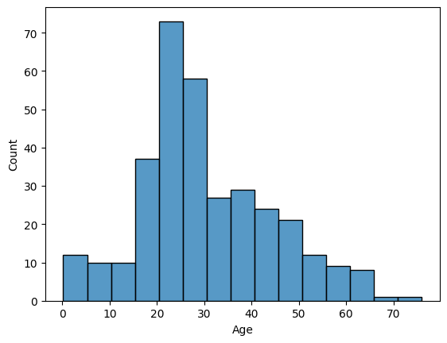

```python
sns.histplot(x="Age",data=dataset1)
plt.show()
```

```python
dataset1["Age"].var()
```

```
201.10669538455943
```

#### STANDARD DEVIATION

##### It is the amount of variation or dispersion of a set of values

```python
np.std(sec1),np.std(sec2)
```

```
(3.559026084010437, 23.18045153428495)
```

```python
std1 = np.sqrt(np.sum(np.abs(sec1-sec1.mean())**2)/len(sec1))
std2 = np.sqrt(np.sum(np.abs(sec2-sec2.mean())**2)/len(sec2))
std1,std2
```

```
(3.559026084010437, 23.18045153428495)
```

```python
dataset1["Age"].std()
```

```
14.181209235624422
```

```python
dataset1.describe()
```

|  | PassengerId | Survived | Pclass | Age | SibSp | Parch | Fare |
| --- | --- | --- | --- | --- | --- | --- | --- |
| count | 418.000000 | 418.000000 | 418.000000 | 332.000000 | 418.000000 | 418.000000 | 418.000000 |
| mean | 1100.500000 | 0.363636 | 2.265550 | 30.272590 | 0.447368 | 0.392344 | 35.553655 |
| std | 120.810458 | 0.481622 | 0.841838 | 14.181209 | 0.896760 | 0.981429 | 55.860735 |
| min | 892.000000 | 0.000000 | 1.000000 | 0.170000 | 0.000000 | 0.000000 | 0.000000 |
| 25% | 996.250000 | 0.000000 | 1.000000 | 21.000000 | 0.000000 | 0.000000 | 7.895800 |
| 50% | 1100.500000 | 0.000000 | 3.000000 | 27.000000 | 0.000000 | 0.000000 | 14.454200 |
| 75% | 1204.750000 | 1.000000 | 3.000000 | 39.000000 | 1.000000 | 0.000000 | 31.471875 |
| max | 1309.000000 | 1.000000 | 3.000000 | 76.000000 | 8.000000 | 9.000000 | 512.329200 |

### 3)PERCENTILES & QUARTILES

##### It is a vlaue below which a certain percentage of observation lies

```python
data1 = pd.read_csv("titanic.csv")
data1.head()
```

|  | PassengerId | Survived | Pclass | Name | Sex | Age | SibSp | Parch | Ticket | Fare | Cabin | Embarked |
| --- | --- | --- | --- | --- | --- | --- | --- | --- | --- | --- | --- | --- |
| 0 | 892 | 0 | 3 | Kelly, Mr. James | male | 34.5 | 0 | 0 | 330911 | 7.8292 | NaN | Q |
| 1 | 893 | 1 | 3 | Wilkes, Mrs. James (Ellen Needs) | female | 47.0 | 1 | 0 | 363272 | 7.0000 | NaN | S |
| 2 | 894 | 0 | 2 | Myles, Mr. Thomas Francis | male | 62.0 | 0 | 0 | 240276 | 9.6875 | NaN | Q |
| 3 | 895 | 0 | 3 | Wirz, Mr. Albert | male | 27.0 | 0 | 0 | 315154 | 8.6625 | NaN | S |
| 4 | 896 | 1 | 3 | Hirvonen, Mrs. Alexander (Helga E Lindqvist) | female | 22.0 | 1 | 1 | 3101298 | 12.2875 | NaN | S |

```python
data1.isnull().sum()
```

```
PassengerId      0
Survived         0
Pclass           0
Name             0
Sex              0
Age             86
SibSp            0
Parch            0
Ticket           0
Fare             0
Cabin          327
Embarked         0
dtype: int64
```

```python
data1.describe()
```

|  | PassengerId | Survived | Pclass | Age | SibSp | Parch | Fare |
| --- | --- | --- | --- | --- | --- | --- | --- |
| count | 418.000000 | 418.000000 | 418.000000 | 332.000000 | 418.000000 | 418.000000 | 418.000000 |
| mean | 1100.500000 | 0.363636 | 2.265550 | 30.272590 | 0.447368 | 0.392344 | 35.553655 |
| std | 120.810458 | 0.481622 | 0.841838 | 14.181209 | 0.896760 | 0.981429 | 55.860735 |
| min | 892.000000 | 0.000000 | 1.000000 | 0.170000 | 0.000000 | 0.000000 | 0.000000 |
| 25% | 996.250000 | 0.000000 | 1.000000 | 21.000000 | 0.000000 | 0.000000 | 7.895800 |
| 50% | 1100.500000 | 0.000000 | 3.000000 | 27.000000 | 0.000000 | 0.000000 | 14.454200 |
| 75% | 1204.750000 | 1.000000 | 3.000000 | 39.000000 | 1.000000 | 0.000000 | 31.471875 |
| max | 1309.000000 | 1.000000 | 3.000000 | 76.000000 | 8.000000 | 9.000000 | 512.329200 |

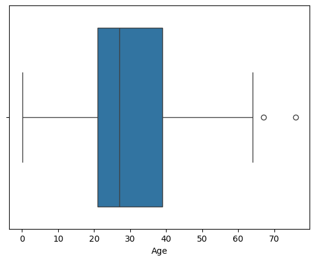

```python
sns.boxplot(x="Age",data=data1)
plt.show()
```

```python
data1["Age"].fillna(data1["Age"].mean())
```

```
0      34.50000
1      47.00000
2      62.00000
3      27.00000
4      22.00000
         ...
413    30.27259
414    39.00000
415    38.50000
416    30.27259
417    30.27259
Name: Age, Length: 418, dtype: float64
```

```python
np.percentile(data1["Age"],25),np.percentile(data1["Age"],75)
```

```
(nan, nan)
```

```python
np.percentile(data1["Age"],0)
```

```
nan
```

```python
data1["Age"].min()
```

```
0.17
```

```python
np.percentile(data1["Age"],100)
```

```
nan
```

```python
data1["Age"].max()
```

```
76.0
```

```python
np.percentile(data1["Age"],50)
```

```
nan
```

```python
data1["Age"].median()
```

```
27.0
```

```python
ds = [2,2,3,4,5,5,5,6,7,8,8,8,8,8,9,9,10,11,11,12]
length = len(ds)
count = 0
x = 10
for i in ds:
    if i == x:
        break
    count += 1
print(count)
percentile_10 = (count / length) * 100
percentile_10
```

```
16
```

```
80.0
```

```python
# what value exists at percentile ranking of 25% ?  - It gives index position
percent = 25
val = (percent / 100) * (length + 1)
val
```

```
5.25
```

#### INTERQUARTILE RANGE

```python
l = [1,2,2,2,3,3,4,5,5,5,6,6,6,6,7,8,8,9,27]
leng = len(l)
```

```python
Q_25 = int((25 / 100) * (leng + 1))
Q_75 = int((75 / 100) * (leng + 1))
print("Index of Q1 = ",Q_25,"\nIndex of Q3 = ",Q_75)

Q1 = l[Q_25-1]
Q3 = l[Q_75-1]
print(Q1,Q3)
```

```
Index of Q1 =  5
Index of Q3 =  15
3 7
```

```python
s = np.percentile(l,25)
p = np.percentile(l,75)
s,p
```

```
(3.0, 6.5)
```

```python
IQR = Q3 - Q1
IQR
```

```
4
```

```python
lower_fen = Q1 - 1.5*IQR
upper_fen = Q3 + 1.5*IQR
lower_fen,upper_fen
```

```
(-3.0, 13.0)
```

[output not shown]

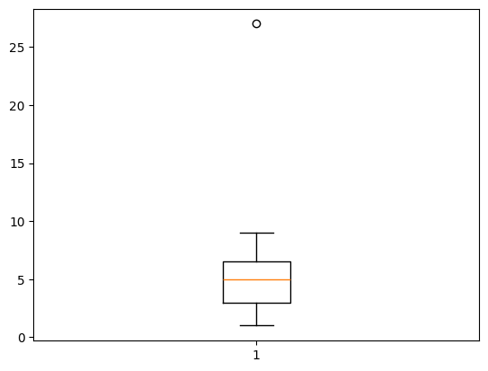

```python
plt.boxplot(l)
```

```python
# therefore 27 is the outlier
```

### 4)Measure Of Shapes

#### Skewness

##### It measures asymmetry of distribution

```python
data1["Age"].skew()
```

```
0.4573612871503845
```

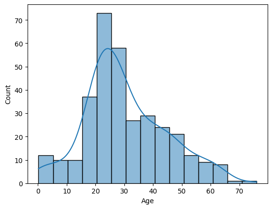

```python
sns.histplot(x="Age",data=data1,kde=True)
plt.show()
```

```python
data1["Age"].mean(),data1["Age"].median(),data1["Age"].mode()[0]
```

```
(30.272590361445783, 27.0, 21.0)
```

```python
data = np.random.normal(0,100,1000)
df = pd.DataFrame({"x":data})
df["x"].skew()
```

```
0.0935778891550577
```

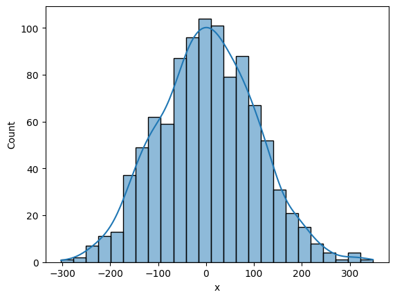

```python
sns.histplot(x="x",data=df,kde=True)
plt.show()
```

```python
var1 = np.sum(np.abs(sec1-sec1.mean())**3)/(len(sec1)-1)
var2 = np.sum(np.abs(sec2-sec2.mean())**3)/(len(sec2)-1)
var1,var2
```

```
(64.0, 15290.4)
```

```python
data1 = [2,3,3,4,4,4,5,5,5,5,5,6,6,6,6,6,7,7,7,7,7,7,8,8,8,8,8,9,9,9,9,10,10,10,11,11,12]
df = pd.DataFrame({"x":data})
df["x"].skew()
```

[output not shown]

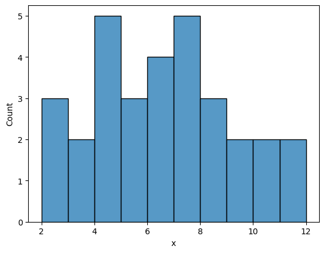

```python
sns.histplot(x="x",data=df,bins=[2,3,4,5,6,7,8,9,10,11,12])
plt.show()
```

```python
df["x"].mean(),df["x"].median(),df["x"].mode()[0]
```

```
(1.9021269638922502, 3.3498851569935013, -325.10127719938146)
```

### 5)COVARIANCE

##### It signifies Linear relationship between two variables

```python
df = pd.read_csv("tips.csv")
df.head()
```

|  | total_bill | tip | sex | smoker | day | time | size |
| --- | --- | --- | --- | --- | --- | --- | --- |
| 0 | 16.99 | 1.01 | Female | No | Sun | Dinner | 2 |
| 1 | 10.34 | 1.66 | Male | No | Sun | Dinner | 3 |
| 2 | 21.01 | 3.50 | Male | No | Sun | Dinner | 3 |
| 3 | 23.68 | 3.31 | Male | No | Sun | Dinner | 2 |
| 4 | 24.59 | 3.61 | Female | No | Sun | Dinner | 4 |

```python
df.isnull().sum()
```

```
total_bill    0
tip           0
sex           0
smoker        0
day           0
time          0
size          0
dtype: int64
```

```python
df.info()
```

```
<class 'pandas.core.frame.DataFrame'>
RangeIndex: 244 entries, 0 to 243
Data columns (total 7 columns):
 #   Column      Non-Null Count  Dtype
---  ------      --------------  -----
 0   total_bill  244 non-null    float64
 1   tip         244 non-null    float64
 2   sex         244 non-null    object
 3   smoker      244 non-null    object
 4   day         244 non-null    object
 5   time        244 non-null    object
 6   size        244 non-null    int64
dtypes: float64(2), int64(1), object(4)
memory usage: 13.5+ KB
```

```python
data_cov = df.select_dtypes(["float64","int64"]).cov()
data_cov
```

|  | total_bill | tip | size |
| --- | --- | --- | --- |
| total_bill | 79.252939 | 8.323502 | 5.065983 |
| tip | 8.323502 | 1.914455 | 0.643906 |
| size | 5.065983 | 0.643906 | 0.904591 |

### 6) CORRELATION

##### It evaluates the strength of a relationship between two variables

```python
data_corr = df.select_dtypes(["float64","int64"]).corr()
data_corr
```

|  | total_bill | tip | size |
| --- | --- | --- | --- |
| total_bill | 1.000000 | 0.675734 | 0.598315 |
| tip | 0.675734 | 1.000000 | 0.489299 |
| size | 0.598315 | 0.489299 | 1.000000 |

#### HEATMAP

##### It is a representation of data in which various values are represented in colors

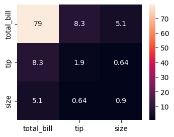

```python
plt.figure(figsize=(4,3))
sns.heatmap(data_cov,annot=True)
plt.show()
```

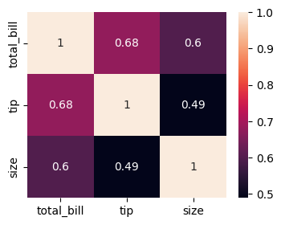

```python
plt.figure(figsize=(4,3))
sns.heatmap(data_corr,annot=True)
plt.show()
```

### 7) FREQUENCY DISTRIBUTION & CUMULATIVE FREQUENCY DISTRIBUTION

##### FD - It shows no.of occurences of each item in the dataset

##### CFD - It shows accumulation i.e., sum of all frequencies

```python
ls1 = ["Rose","Lilly","Sunflower","Rose","Lilly","Sunflower","Rose","Lilly","Lilly"]
count_rose = 0
count_lilly = 0
count_sun = 0
for i in ls1:
    if i == "Rose":
        count_rose += 1
    elif i == "Lilly":
        count_lilly += 1
    elif i == "Sunflower":
        count_sun += 1
print("Frequency Distribution:")
print(f"Rose = {count_rose}, Lilly = {count_lilly}, Sunflower = {count_sun}")
```

```
Frequency Distribution:
Rose = 3, Lilly = 4, Sunflower = 2
```

```python
d = { "Flowers" : ["Rose","Lilly","Sunflower"],
      "Frequency" : [count_rose,count_lilly,count_sun]
    }
df = pd.DataFrame(d)
df["CDF"] = df["Frequency"].cumsum()
df
```

|  | Flowers | Frequency | CDF |
| --- | --- | --- | --- |
| 0 | Rose | 3 | 3 |
| 1 | Lilly | 4 | 7 |
| 2 | Sunflower | 2 | 9 |

#### Bar Graph

##### For dicrete values we use bar graphs

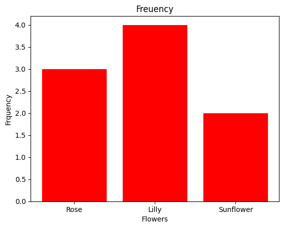

```python
plt.bar(df["Flowers"],df["Frequency"],color="red")
plt.title("Freuency")
plt.xlabel("Flowers")
plt.ylabel("Frquency")
plt.show()
```

#### Histograms

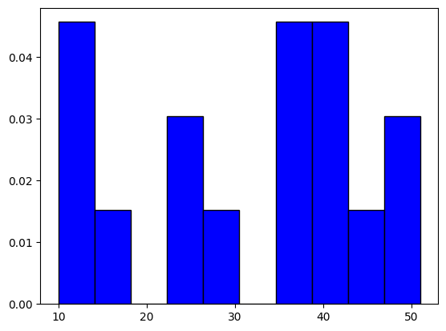

```python
ages = [10,12,14,18,24,26,30,35,36,37,40,41,42,43,50,51]
plt.hist(ages,color="blue",ec="black",bins=10,density=True)
```

## INFERENTIAL STATISTICS

##### It draws conclusions from the data

### 1) CENTRAL LIMIT THEOREM

##### It states that when plotting a sample distribution of means then the means of sample will be equal to population mean.Sample Distribution will approach normal distribution with variance equal to standard error.

```python
pdata = [np.random.randint(10,100) for i in range(10000)]
len(pdata)
```

```
10000
```

```python
ptable = pd.DataFrame({"Pdata" : pdata})
ptable
```

|  | Pdata |
| --- | --- |
| 0 | 40 |
| 1 | 16 |
| 2 | 92 |
| 3 | 10 |
| 4 | 20 |
| ... | ... |
| 9995 | 93 |
| 9996 | 42 |
| 9997 | 12 |
| 9998 | 83 |
| 9999 | 77 |

10000 rows × 1 columns

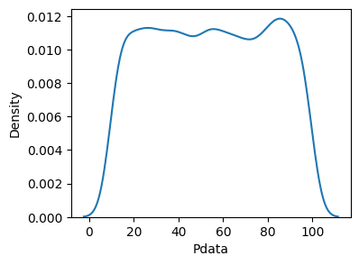

```python
# kde - kernel density estimate
# It represents the data using a continuous probability density curve in one or more dimensions

plt.figure(figsize=(4,3))
sns.kdeplot(x="Pdata",data=ptable)
plt.show()
```

```python
sample_mean = []
for i in range(60):
    sample_data = []
    for j in range(500):
        sample_data.append(np.random.choice(pdata))
    sample_mean.append(np.mean(sample_data))
```

```python
sample_M = pd.DataFrame({"Sample Mean":sample_mean})
```

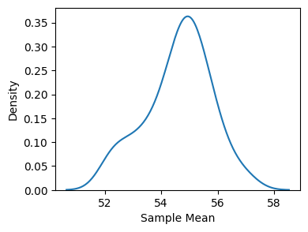

```python
plt.figure(figsize=(4,3))
sns.kdeplot(x="Sample Mean",data=sample_M)
plt.show()
```

```python
np.mean(sample_mean)
```

```
54.6113
```

### 2) HYPOTHESIS TESTING

##### In this we test the assumptions made regarding a population parameter.

#### Z Test

##### If population mean & standard deviation are known and also the sample size is>= 30, we do Z test

##### Q1) A teacher claims that the mean score of students in his class is greater than 82 with a standard deviation of 20.If a sample of 81 students are selected with a mean score of 90 with alpha = 0.05

```python
import scipy.stats as st
```

```python
sample_mean = 90
population_mean = 82
population_std = 20
no_of_samples = 81
alpha = 0.05

z_cal = ((sample_mean - population_mean)/(population_std / np.sqrt(no_of_samples)))
z_cal
```

```
3.5999999999999996
```

```python
z_table = st.norm.ppf(1- alpha)
z_table
```

```
1.6448536269514722
```

```python
if z_cal > z_table:
    print("Reject H0")
else:
    print("Accept H0")
```

```
Reject H0
```

##### Q2) You have collected data from a random sample of 30 customers who made purchases on the old website design & 30 customers who made purchases on the new website design as below.Does the new website design has lead to significance increase in the average purchase amount compared to the old design. (Population old mean = Population new mean)

```python
old_data = [45.2,42.8,38.9,43.5,41.0,44.6,40.5,42.7,39.8,41.4,44.3,39.7,42.1,40.6,43.0,42.2,41.5,39.6,44.0,43.1,38.7,43.9,42.0,41.9,42.8,43.7,41.3,40.9,42.5,41.6]
new_data = [48.5,49.1,50.2,47.8,48.7,49.9,48.0,50.5,49.8,49.6,48.2,48.9,49.7,50.3,49.4,50.1,48.6,48.3,49.0,50.0,48.4,49.3,49.5,48.8,50.6,50.4,48.1,49.2,50.7,50.8]
pop_std = 2.5
no_of_samples = len(new_data)
alp = 0.05
```

```python
mean_old = np.mean(old_data)
mean_new = np.mean(new_data)
mean_old,mean_new
```

```
(41.99333333333333, 49.346666666666664)
```

```python
z_cal = (mean_new - mean_old)/(pop_std/np.sqrt(no_of_samples))
z_cal
```

```
16.11034615808528
```

```python
z_tab = st.norm.ppf(1-alp)
z_tab
```

```
1.6448536269514722
```

```python
if z_cal > z_table:
    print("Reject H0")
else:
    print("Accept H0")
```

```
Reject H0
```

#### T Test

##### If Sample mean & standard deviation are known and also the sample size is < 30, we do T test

##### Q1) A manufacturer claims that the average weight of a bag of potato chips is 150 grams. A sample of 25 bags is taken, and the average weight is found to be 148 grams,with a standard deviation of 5 grams.Test the manufacturer's claim using a one-tailed t-test with a significance level of 0.05.

```python
pop_mean = 150
sample_mean = 148
sample_std = 5
no_of_samples = 25
alp = 0.05
```

```python
degree_of_freedom = no_of_samples - 1
degree_of_freedom
```

```
24
```

```python
t_tab = st.t.ppf(0.05,24)
t_tab
```

```
-1.7108820799094282
```

```python
t_cal = ((sample_mean - population_mean)/(sample_std / np.sqrt(no_of_samples)))
t_cal
```

```
66.0
```

```python
if t_cal > t_tab:
    print("Reject H0")
else:
    print("Accept H0")
```

```
Reject H0
```

##### Q2) A company wants to test whether there is a difference in productivity between two teams.They randomly select 20 employees from each team and record their productivity scores.The mean productivity score for Team A is 80 with a standard deviation of 5,while the mean productivity score for Team B is 75 with a standard deviation of 6.Test at a 5% level of significance whether there is a difference productivity between the two teams.

```python
no_of_samples = 20
mean_A = 80
std_A = 5
mean_B = 75
std_B = 6
alp = 0.05
```

```python
deg_free = no_of_samples + no_of_samples - 2
deg_free
```

```
38
```

```python
t_tab = st.t.ppf(1-(alp/2),deg_free)
t_tab
```

```
2.024394164575136
```

```python
t_cal = (mean_A - mean_B)/np.sqrt((std_A**2/no_of_samples)+(std_B**2/no_of_samples))
t_cal
```

```
2.862991671569341
```

```python
if t_cal > t_tab:
    print("Reject H0")
else:
    print("Accept H0")
```

```
Reject H0
```

#### Chi-Square Test

##### It is non-parametric test that is performed on categorical data

##### It measures Goodness and independence

##### Q1) A fair die is rolled 120 times & the following results are obtained:

##### Face1 :22 times

##### Face2 :17 times

##### Face3 :20 times

##### Face4 :26 times

##### Face5 :22 times

##### Face6 :13 times

##### Test at a 5% level of significance whether the die is fair.

```python
ori = np.array([22,17,20,26,22,13])
exp = np.array([20,20,20,20,20,20])
deg_free = 5
alp = 0.05

chi_cal = np.sum((ori-exp)**2/exp)
chi_cal
```

```
5.1000000000000005
```

```python
chi_tab = st.chi2.ppf(1-(alp),5)
chi_tab
```

```
11.070497693516351
```

```python
if chi_cal > chi_tab:
    print("Reject H0")
else:
    print("Accept H0")
```

```
Accept H0
```